# Workshop 19_11_07

Stefan Haußner

6 November 2019

# Preface

Benötigte Pakete und Netzwerkdaten laden

```r
library(openxlsx)
library(tidyverse)
library(janitor)
library(countrycode)
library(igraph)
library(ggrepel)
library(ggthemes)
```

```r
load("../data/data_preprocessed.Rdata")
```

# Combining network data with supplementary data

Wir haben in Sarajevo entschieden, dass wir unsere Daten in Zusammenhang mit unseren grundlegenden Annahmen und Thesen stellen. Hierzu haben wir zwei grobe Themenblöcke definiert:

- Wirtschaftliche Beziehungen
- Sozio-kulturelle Verbindungen

Um die These(n) zu prüfen haben wir unabhängige Variablen definiert (siehe Tabelle im Protokoll)

I. Wirtschaftliche Beziehungen

- Gesamthandelsvolumen (Jonas)
- FDI (Nastja)
2. Sozio-kulturelle Verbindungen
- Remittances (Arbeitsmigration) (Yunus)
- Botschaften (Fedor)
- EU-Bürger_innen in Drittstaaten (Arbeitsmigration) (Katharina)

## Datenaufbereitung Turnover Jonas

Stefan: Ich habe die Daten so aufbereitet, dass sie im “Long-Format” vorliegen. Das bedeutet eine Spalte Handelspartnerland, eine Spalte EU-Land und eine Spalte den value (hier Handelsvolumen). Das kommt der Struktur der *edge list* des Netzwerks am nächsten.

Die urspünglichen Daten lagen im “Wide-Format” vor, also eine Spalte mit Handelspartner und dann als “Kopfzeile” die EU28 und in den jeweiligen Zellen den Value.

```r
turnover_raw <- openxlsx::read.xlsx("../data/19_Turnover_Jonas_nicht_zugeordnet_10-30.xlsx",
                                    sheet = 1, startRow = 12, na.strings = "not available") %>%
  tbl_df() %>%
  clean_names() %>%
  rename(belgium = belgium_and_luxbg_1998,
         czechia = czechia_cs_1992,
         germany = germany_incl_dd_from_1991) %>%
  select(partner_reporter:slovakia, croatia) %>%
  filter(!(row_number() %in% 273:280))

turnover_prepared <- turnover_raw %>%
  gather(austria:croatia, key = country, value = value) %>%
  mutate(iso_host = countrycode(sourcevar = partner_reporter, origin = "country.name", "iso3c"),
         iso_guest = countrycode(sourcevar = country, origin = "country.name", "iso3c"),
         value = round(value, 6))
```

## Datenaufbereitung von Freihandelsabkommen mit EU und Botschaften

```r
fta_embassy_prepared <- openxlsx::read.xlsx("../data/19_Datensammlung_Reisediplomatie Projekt_Gesamt_Bilateral_mit_ind._Variablen_11-25.xlsx", sheet = 2) %>%
  clean_names() %>% tbl_df() %>%
  select(eu_land, gastland = gastland_gesprachspartner_bei_multilateralen_treffen,
         fta = freihandelsabkommen_mit_der_eu_1_ja_2_nein,
         embassy = botschaft_ja_1_nein_2_des_eu_landes_in_gastland) %>%
  mutate(gastland = case_when(gastland == "Canada" ~ "Kanada",
                              gastland == "Egypten" ~ "Ägypten",
                              gastland == "Indonesia" ~ "Indonesien",
                              gastland == "Morokko" ~ "Marokko",
                              gastland == "Venesuela" ~ "Venezuela",
                              TRUE ~ gastland)) %>%
  mutate(fta = abs(fta-2),
         embassy = abs(embassy-2),
         iso3_eu = countrycode(eu_land, "country.name.de","iso3c"),
         iso3_host = countrycode(gastland, "country.name.de","iso3c")) %>%
  filter(!is.na(iso3_host))
```

# Preparing supplementary data for merging with network-graph

Einige der Zeilen sind nicht “eindeutig”, da es z.B. zwei Beobachtungen für DNK und RUS (Russische Föderation und Sowjetunion) gibt. Filtern durch eine Flag für “unique” UND-Wert über 0 ODER EQUAL.

Aufgrund der oben beschriebenen Probleme mit doppelten Zeilen werden die Daten hier nochmals aufbereitet und schließlich über *left_join* an die die edge-list des Netzwerkes gematched. Dabei wir quasi geschaut, wo die BEIDEN Spalten iso3_eu und iso3_host übereinstimmen.

```r
turnover_prepared_2 <- left_join(rd_ready, turnover_prepared, by = c("iso3_eu" = "iso_guest", "iso3_host" = "iso_host")) %>%
  select(iso3_eu, iso3_host, value, partner_reporter) %>%
  group_by(iso3_eu, iso3_host) %>%
  arrange(value, .by_group = TRUE) %>%
  mutate(n = n(),
         lag = value - lag(value)) %>%
  mutate(filter_mark = (n > 1 & lag == 0),
         filter_mark = case_when(is.na(filter_mark) ~ FALSE,
                                 TRUE ~ filter_mark)) %>%
  filter(filter_mark == FALSE, !is.na(value)) %>%
  ungroup() %>%
  group_by(iso3_eu, iso3_host) %>%
  arrange(value, .by_group = TRUE) %>%
  mutate(n = n()) %>%
  filter(n == 1 | (n > 1 & lag > 0))

addvars_network_data <- left_join(rd_ready, turnover_prepared_2, by = c("iso3_eu", "iso3_host")) %>%
  select(iso3_eu, iso3_host, turnover = value) %>%
  left_join(., fta_embassy_prepared, by = c("iso3_eu","iso3_host"))
```

# Regionendossiers

## Extrahieren von Regionen aus dem Gesamtnetzwerk

Hier wird das Netzwerk der einzelnen Regionen aus dem Gesamtnetzwerk extrahiert. Der Code ist so aufgebaut, dass nur das Objekt *countries_of_interest* geändert werden muss, um eine andere Region zu analysieren.

Dazu müssen eben alle ISO3-Codes der jeweiligen Länder in einer Region (oder von euch gesetzten Zusammenstellung) gesucht werden. Natürlich geht auch “Großmächte” oder “EU-Beitrittskandidaten” etc.

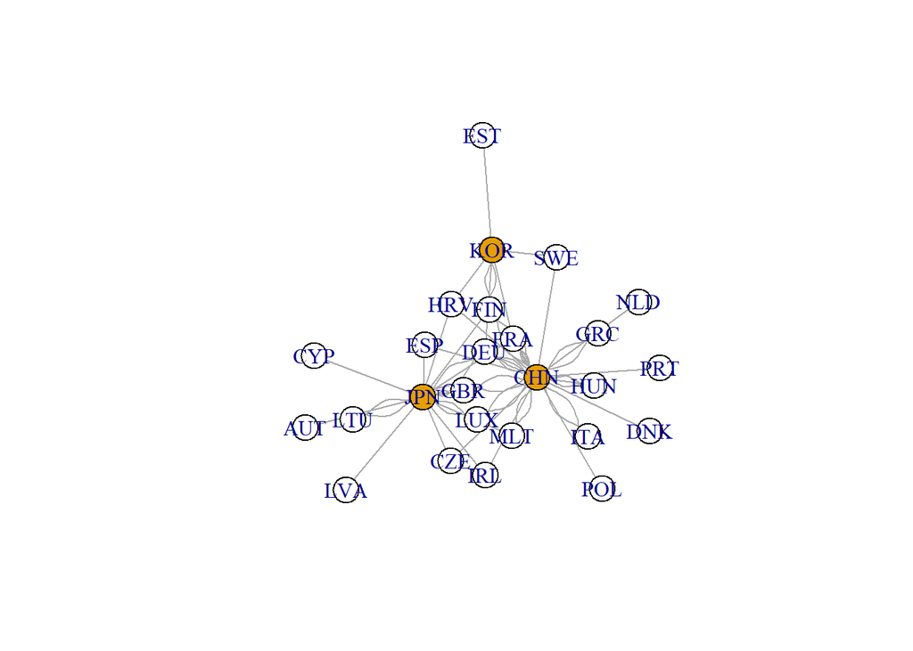

```r
#countries_of_interest <- c("BLZ", "CRI","SLV","GTM","HND","MEX","NIC","PAN")
countries_of_interest <- c("CHN", "HKG","JPN","PRK","KOR","MAC","MNG")


rd_region <- rd_ready %>%
  filter(iso3_host %in% countries_of_interest) %>%
  graph.data.frame(directed = FALSE)

V(rd_region)$type <- V(rd_region)$name %in% countries_of_interest

plot.igraph(rd_region, vertex.color = V(rd_region)$type)
```

## Layouten

tbc.

## Analyse

### Bipartite Projektion der EU28

> Erinnerung: Unser Netzwerk ist ein bipartites Netz, weil es aus 2 klar abgegrenzten Gruppen besteht (EU28 und Gastländer). Die Projektionen dieses Netzwerkes bilden dann ein Netzwerk aus EINER Gruppe dieser Länder.

Eine Verbindung zwischen D und F besteht bspw. dann, wenn die beiden Länder im Datensatz mal Guatemala besucht haben. Darüber hinaus wird automatisch das Attribut *weight* im Netzwerk erzeugt. Dieses Attribut beschreibt, wieviele gemeinsame Länder D und F besucht haben.

Hier habe ich dieses Gewicht als Möglichkeit genutzt, die Verbindungslinien umso stärker zu machen, je mehr gemeinsame Besuchsländer zwei Knotenpunkte hatten.

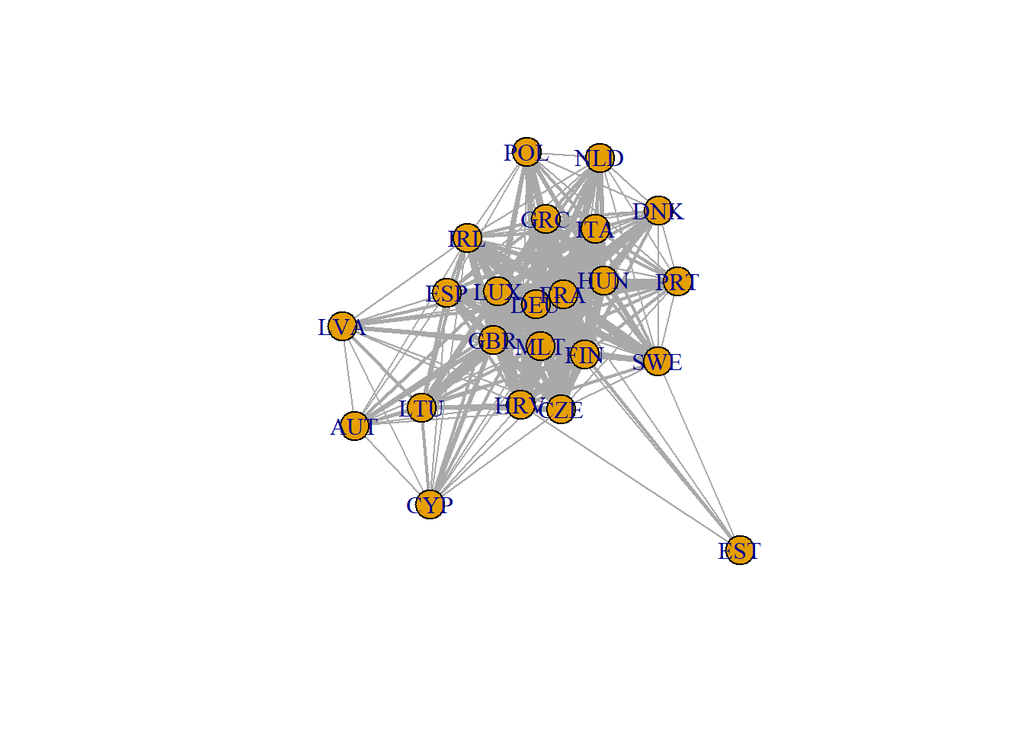

```r
rd_projection <- bipartite.projection(rd_region)
rd_projection_eu <- rd_projection$proj1

plot.igraph(rd_projection_eu, edge.width = E(rd_projection_eu)$weight)
```

```r
E(rd_projection_eu)$weight
```

```
##   [1]  4  2  5  2  1  2  1  2  2  1  1  1  1  1  1  3  2 12 23  8  6  8  7
##  [24] 12 10  4  4  4  5  6  6 12 14  2  4  2  2  1  2  1  1  1 13  4  3  4
##  [47]  5  6  5  2  2  2  4  3  3  6  7  1  2  1  1 10  6 10  7 12 11  5  5
##  [70]  5  6  6  6 15 13  1  2  1  1  2  4  2  4  4  2  2  2  2  2  2  6  4
##  [93]  2  2  4  3  1  1  1  1  2  2  3  5  1  2  1  1  2  4  4  2  2  2  2
## [116]  2  2  6  4  4  3  1  1  1  2  2  2  3  5  1  2  1  1  2  2  1  1  1
## [139]  1  3  1  4  2  2  2  2  6  2  6  2  2  2  2  4  4  6 10  2  2  2  2
## [162]  2  2  3  3  6  7  1  1  1  1  1  1  1  3  2  1  1  3  1  1  1  1  1
## [185]  3  2  1  1  1  3  2  1  1  3  2  2  3  5  1  3  5  1  6  3
```

# Verknüpfung von Zentralitätswerten des Netzwerks mit supplementary data

Schließlich müssen wir die Ergebnisse unserer Analysen zusammenbringen mit den zusätzlichen Werten, die ihr recherchiert habt (hier als Beispiel das Handelsvolumen).

Der erste Block beinhaltet die Auswahl für die Handelsdaten. Die Daten werden erst gefiltert, dass wieder nur die Zeilen vorhanden sind, die uns auch interessieren (countries_of_interest). Anschließend werden die Daten gruppiert, nach den EU-Staaten und anschließend pro Gruppe das Handelsvolumen aufsummiert (geht, weil prozentual). Somit haben wir am Ende eine Tabelle mit dem Handelsvolumen des EU-Landes in die jeweilige Region.

Die weiteren beiden Blöcke generiert ein Objekt mit den Zentralitätsmaßen *Eigenvector-centrality* und *Strength*. Der letzte Block fasst diese Daten zusammen (*left_join*) und plottet.

```r
addvars_in_region <- addvars_network_data %>%
  filter(iso3_host %in% countries_of_interest) %>%
  distinct() %>%
  group_by(iso3_eu) %>%
  summarise(turnover_in_region = sum(turnover),
            fta_in_region = sum(fta, na.rm = TRUE),
            embassies_in_region = sum(embassy, na.rm = TRUE))
```

```r
region_eigen <- eigen_centrality(rd_projection_eu, weights = E(rd_projection_eu)$weight)$vector %>%
  data.frame() %>%
  rownames_to_column(var = "iso3_eu") %>%
  rename(eigenvector_centr = ".")
```

```r
region_strength <- strength(rd_projection_eu) %>%
  data.frame() %>%
  rownames_to_column(var = "iso3_eu") %>%
  rename(strength = ".")
```

Verknüpfung über left_join aller Daten

```r
region_dataset <- left_join(region_eigen, region_strength, by = "iso3_eu") %>%
  left_join(., addvars_in_region, by = "iso3_eu")

region_dataset_long <- region_dataset %>%
  gather(c(turnover_in_region, fta_in_region, embassies_in_region), key = "indvar", value = "value")
```

# Analysis

## Plots für strength

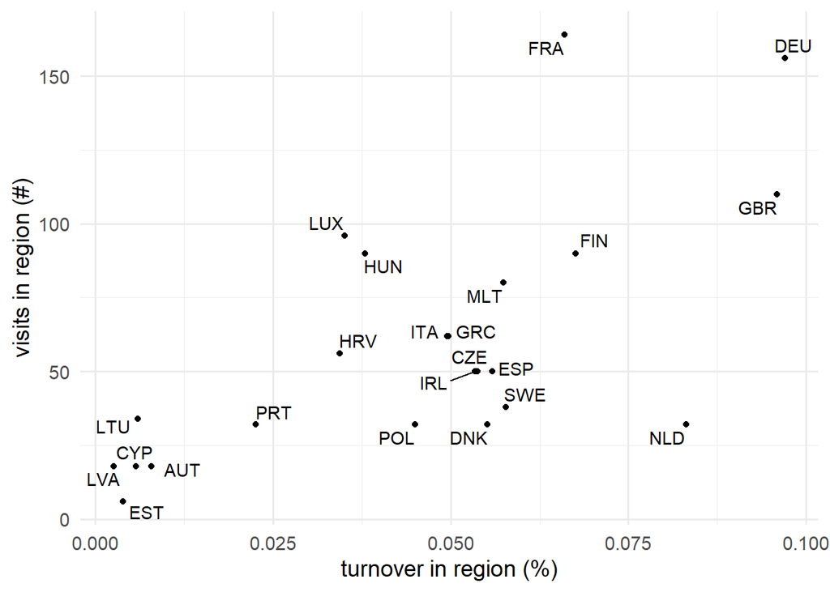

```r
ggplot(region_dataset, aes(x = turnover_in_region, y = strength))+
  #geom_smooth(method = "lm", alpha = 0.2)+
  geom_point()+
  geom_text_repel(aes(label = iso3_eu))+
  theme_minimal(base_size = 14)+
  labs(x = "turnover in region (%)",
       y = "visits in region (#)")
```

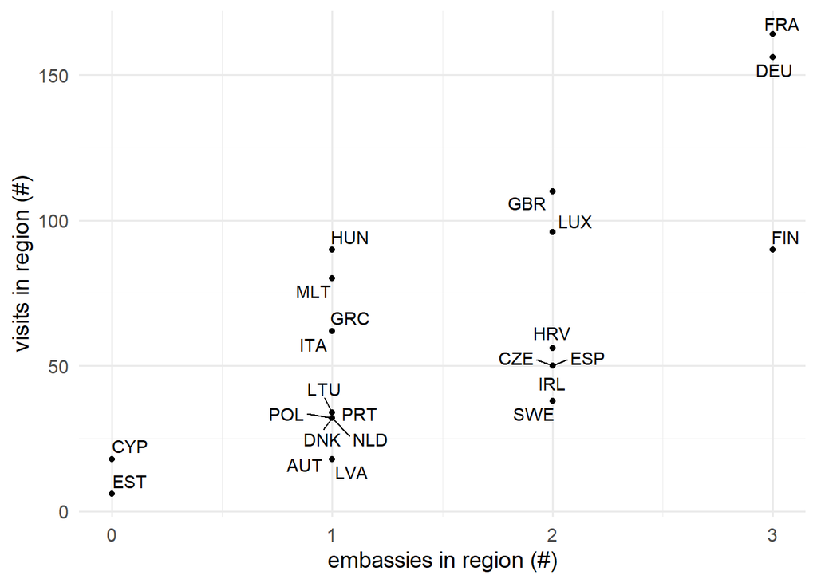

```r
ggplot(region_dataset, aes(x = embassies_in_region, y = strength))+
  #geom_smooth(method = "lm", alpha = 0.2)+
  geom_point()+
  geom_text_repel(aes(label = iso3_eu))+
  theme_minimal(base_size = 14)+
  labs(x = "embassies in region (#)",
       y = "visits in region (#)")
```

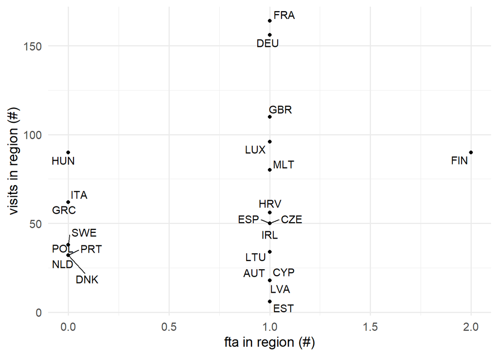

```r
ggplot(region_dataset, aes(x = fta_in_region, y = strength))+
  #geom_smooth(method = "lm", alpha = 0.2)+
  geom_point()+
  geom_text_repel(aes(label = iso3_eu))+
  theme_minimal(base_size = 14)+
  labs(x = "fta in region (#)",
       y = "visits in region (#)")
```

## Plots für eigenvector centrality

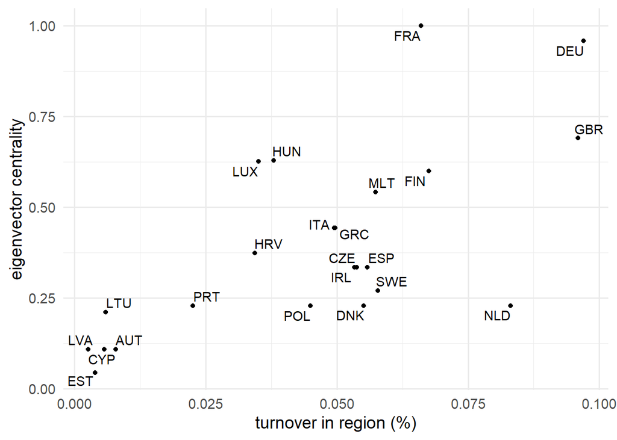

```r
ggplot(region_dataset, aes(x = turnover_in_region, y = eigenvector_centr))+
  #geom_smooth(method = "lm", alpha = 0.2)+
  geom_point()+
  geom_text_repel(aes(label = iso3_eu))+
  theme_minimal(base_size = 14)+
  labs(x = "turnover in region (%)",
       y = "eigenvector centrality")
```

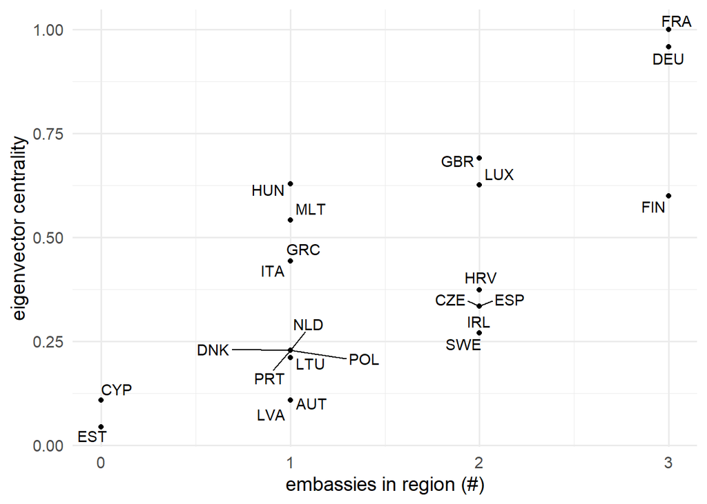

```r
ggplot(region_dataset, aes(x = embassies_in_region, y = eigenvector_centr))+
  #geom_smooth(method = "lm", alpha = 0.2)+
  geom_point()+
  geom_text_repel(aes(label = iso3_eu))+
  theme_minimal(base_size = 14)+
  labs(x = "embassies in region (#)",
       y = "eigenvector centrality")
```

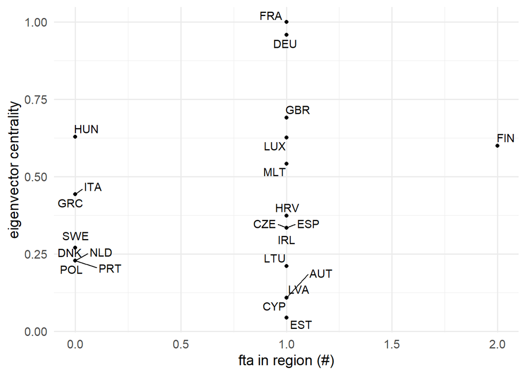

```r
ggplot(region_dataset, aes(x = fta_in_region, y = eigenvector_centr))+
  #geom_smooth(method = "lm", alpha = 0.2)+
  geom_point()+
  geom_text_repel(aes(label = iso3_eu))+
  theme_minimal(base_size = 14)+
  labs(x = "fta in region (#)",
       y = "eigenvector centrality")
```